# Chapter 03 Exercises

## Q4) Growh rates of per capita GDP:

**(a)** Compute the average annual growth rate of per capita GDP for each of the countries listed below. The levels of GDP per capital are provided for 1980 and 2014, measured in constant 2011 dollars.

*Hint: We will use formula (3.9) on page 54 of your textbook. The comments in the input field below will guide you through this exercise.*

```python
# The following are lists containing the information described above.

names=['United States','Canada','France','United Kingdom','Italy','Germany','Japan','Ireland','Mexico','Brazil','Indonesia','Kenya','China','India','Ethiopia']
GDP_1980=[29288, 24716, 22557, 20044, 19912, 19617, 19147, 12845, 11954, 5297, 2249, 2049, 1578, 1196, 690]
GDP_2014=[51958, 43376, 37360, 38083, 34876, 45320, 35574, 52186, 15521, 17459, 9797, 2971, 12514, 5451, 1505]


# Step 1: Turn these pre-defined lists into a dictionary called "gdp_dictionary"
gdp_dictionary = {'Country': names, 'GDP 1980': GDP_1980, 'GDP 2014': GDP_2014}

#Step2: Convert your GDP dictionary into a DataFrame called "gdp_df"

gdp_df = pd.DataFrame(gdp_dictionary)

# Step 3: Use a custom function to calculate the average growth rate of GDP between 1980 and 2014 for all the countries at the same time.
# Append you calculated field as another column on the "gdp_df" dataframe.
AVG_gr = ((np.log(gdp_dictionary['GDP 2014']) - np.log(gdp_dictionary['GDP 1980'])) / 34) * 100

AVG_gr1 = ((np.array(gdp_dictionary['GDP 2014']) / np.array(gdp_dictionary['GDP 1980']))**(1/34) - 1) * 100

gdp_df['Average GDP growth rate(continuous)'] = AVG_gr

gdp_df['Average GDP growth rate(discrete)'] = AVG_gr1

#Step 4: Print your ouput
print(gdp_df)
```

```
           Country  GDP 1980  GDP 2014  Average GDP growth rate(continuous)  \
0    United States     29288     51958                             1.686052
1           Canada     24716     43376                             1.654281
2           France     22557     37360                             1.483986
3   United Kingdom     20044     38083                             1.887759
4            Italy     19912     34876                             1.648460
5          Germany     19617     45320                             2.462800
6            Japan     19147     35574                             1.821968
7          Ireland     12845     52186                             4.123117
8           Mexico     11954     15521                             0.768024
9           Brazil      5297     17459                             3.507984
10       Indonesia      2249      9797                             4.328207
11           Kenya      2049      2971                             1.092784
12           China      1578     12514                             6.090264
13           India      1196      5451                             4.461225
```

[output cut: 18 more lines]

**(b)** In part **(a)** you found the average growth rates for various countries. Do you think that there are some growth rates that are more common than others? Create a histogram and find out!

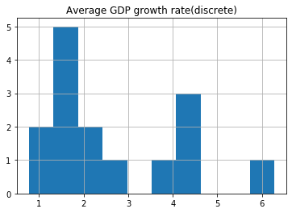

```python
# Hint: you can directly plot a histogram from the DataFrame if you don't want a lot of customization (google it!).
#Otherwise you can use "matplotlib.pyplot.hist"
hist = gdp_df.hist(column = 'Average GDP growth rate(discrete)')
```

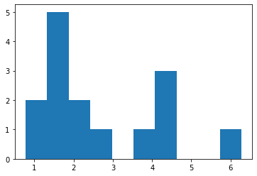

```python
plt.hist(gdp_df['Average GDP growth rate(discrete)'])
plt.show()
```

## Q5) Practice Charting in Python

a) The code below will walk you through importing data on Amazon's (AMZN) stock price over time. Create a time series plot of the stock price with time on the x-axis and price on the y-axis. Don't forget to make the graph look professional by including a proper lables, title, and some color to the data being plotted.

*Hint: If you need a reminder on how to use Matplotlib, please see the DataCamp course "Intermediate Python for Data Science" section 1, or the Python Guide on Matplotlib on I-learn.*

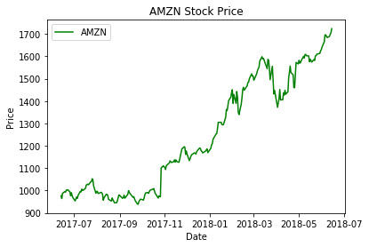

```python
# Step 1: Import the data from Git Hub

amzn = pd.read_csv('https://raw.githubusercontent.com/dylanjm/econ_381_development/master/data/AMZN.csv')

# Step 2: Create x and y axis variables for plotting.

#  date = np.array(amzn["Date"], dtype=np.datetime64)
amzn['Date'] = pd.to_datetime(amzn["Date"])
amzn['Year'] = amzn['Date'].dt.year

price = np.array(amzn["Close"])

# Step 3: Insert your code below to make the time series plot using Python's Matplotlib.
##  plt.plot(date, price, color = 'green', label = 'AMZN')
plt.plot(amzn['Date'], price, color ='green', label = 'AMZN')

# Defining the plot
plt.ylabel('Price')
plt.xlabel('Date')
plt.title('AMZN Stock Price')
plt.legend()

# definition
plt.show()
```

b) The constant growth rate formula (both discrete and continuous) we have used throughout this assignment has many uses and different names. This same formula is used in Finance to calculate average returns for a miriad of assets. Let's use the discrete version of the formula to compute an average percent return for Amazon's stock prices during the time period we have data. You will use exactly the same formula from Q4 part (a), taking the first observation in "price" as $y_0$ and the last observation as $y_t$. Make sure that you calculate $t$ in years.

```python
# Step 1: locate the first and last observations of the "price" array, store them as numpy array variables "y_"0 and "y_t"

yo = price[0]
yt = price[-1]
#Step 2: calculate how many years have passed between the first and last observations in the "date" array corresponding
#to our price observations.

time1 = np.array(amzn['Year'])
t = time1[-1] - time1[0]

#Step 3: Use formula (3.9) in page 54 of the textbook.

r = ((yt/yo)**(1/t) - 1) * 100

#Step 4: Print your output!
print('constant growth rate is %', r)
```

```
constant growth rate is % 76.539989574344
```